# Company Reputation Poll EDA

Reputables

2022-06-19

# Introduction

Many factors affect the reputation of companies. Axios and Harris have studied the reputations of the top 100 companies in the United States of America based on surveys that cover the opinions of more than 33,000 participants that have been conducted since 2002. In this report, the focus will be to explore companies’ reputations over the last five years.

# Data

This data is the result of a partnership between Axios and Harris Poll to gauge the reputation of the most visible companies in America, based on 20 years of Harris Poll research.

## Methodology

The Axios Harris Poll 100 is based on a survey of 33,096 Americans in a nationally representative sample conducted from March 11 to April 3, 2022. The two-step process starts fresh each year by surveying the public’s top-of-mind awareness of companies that either excel or falter in society. The poll only covers 100 companies that are classified as “most visible companies”. The classification process is based on the count of the most repeated 100 companies in the representative sample’s poll.

## Data Dictionary

The dataset contains two separate files, `poll.csv` and `reputation.csv`. The poll file contains information about the rank and RQ score from 2017 to 2022, while the reputation file contains the scores of the 7 attributes in 2022 only.

### Poll data

Description of the parameters in the poll.csv file

| variable | class | description |
| --- | --- | --- |
| company | character | Company Name |
| industry | character | Industry group |
| 2022_rank | integer | 2022 Rank (1 is better than 100) |
| 2022_rq | double | 2022 RQ score. An RQ score is calculated by: [ (Sum of ratings of each of the 9 attributes)/(the total number of attributes answered x 7) ] x 100. Score ranges: 80 & above: Excellent; 75-79: Very Good… |
| change | integer | Change in rank from 2021 |
| year | integer | Year for that rank/RQ |
| rank | integer | Rank corresponding to the year |
| rq | double | RQ score corresponding to the year |

`poll.csv`

| company | industry | 2022_rank | 2022_rq | change | year | rank | rq |
| --- | --- | --- | --- | --- | --- | --- | --- |
| Trader Joe's | Retail | 1 | 82.4 | NA | 2017 | NA | NA |
| Trader Joe's | Retail | 1 | 82.4 | NA | 2018 | NA | NA |
| Trader Joe's | Retail | 1 | 82.4 | NA | 2019 | NA | 78.2 |
| Trader Joe's | Retail | 1 | 82.4 | NA | 2020 | NA | 80.7 |
| Trader Joe's | Retail | 1 | 82.4 | NA | 2021 | NA | NA |
| HEB Grocery | Retail | 2 | 82 | NA | 2017 | NA | NA |
| HEB Grocery | Retail | 2 | 82 | NA | 2018 | NA | 81.1 |
| HEB Grocery | Retail | 2 | 82 | NA | 2019 | NA | 82.5 |
| HEB Grocery | Retail | 2 | 82 | NA | 2020 | NA | 83.1 |
| HEB Grocery | Retail | 2 | 82 | NA | 2021 | NA | NA |

[output cut: 490 more lines]

### Reputation data

Description of the parameters in the reputation.csv file.

| variable | class | description |
| --- | --- | --- |
| company | character | Company Name |
| industry | character | Industry group |
| name | character | Name of reputation category (P&S = Product and Service) |
| score | double | Score for reputation category |
| rank | integer | Rank for reputation category |

`reputation.csv`

| company | industry | name | score | rank |
| --- | --- | --- | --- | --- |
| Trader Joe's | Retail | TRUST | 82.72 | 3 |
| Trader Joe's | Retail | ETHICS | 82.5 | 2 |
| Trader Joe's | Retail | GROWTH | 84.11 | 2 |
| Trader Joe's | Retail | P&S | 83.51 | 10 |
| Trader Joe's | Retail | CITIZENSHIP | 79.96 | 3 |
| Trader Joe's | Retail | VISION | 81.94 | 13 |
| Trader Joe's | Retail | CULTURE | 83.05 | 1 |
| HEB Grocery | Retail | TRUST | 83.74 | 1 |
| HEB Grocery | Retail | ETHICS | 81.75 | 4 |
| HEB Grocery | Retail | GROWTH | 83.61 | 4 |

[output cut: 690 more lines]

# Explanatory Data Analysis (EDA)

## Poll EDA

### Data munging

Now, the summary of the poll data is represented below. Some parameters have NA values which means that the data requires cleaning before starting the analysis. However, these NA are not meaningless, as the NA in “change” conveys that the company did not change its ranking between at least two following years.

```
##    company            industry           2022_rank         2022_rq
##  Length:500         Length:500         Min.   :  1.00   Min.   :54.50
##  Class :character   Class :character   1st Qu.: 25.75   1st Qu.:70.88
##  Mode  :character   Mode  :character   Median : 50.50   Median :75.40
##                                        Mean   : 50.50   Mean   :74.19
##                                        3rd Qu.: 75.25   3rd Qu.:78.25
##                                        Max.   :100.00   Max.   :82.40
##
##      change              year           rank              rq
##  Min.   :-71.0000   Min.   :2017   Min.   :  1.00   Min.   :49.11
##  1st Qu.: -6.0000   1st Qu.:2018   1st Qu.: 22.50   1st Qu.:70.47
##  Median :  1.0000   Median :2019   Median : 46.00   Median :74.70
##  Mean   :  0.3704   Mean   :2019   Mean   : 47.14   Mean   :73.66
##  3rd Qu.:  7.0000   3rd Qu.:2020   3rd Qu.: 70.00   3rd Qu.:78.10
##  Max.   : 29.0000   Max.   :2021   Max.   :100.00   Max.   :86.27
##  NA's   :95         NA's   :1      NA's   :153      NA's   :84
```

First, the data must be cleaned from replicates and NAs.

Second, in the poll, there are two redundant columns for the rank and the RQ score of 2022. Hence, these columns will be removed and their contents will be merged with the rank and RQ columns, and cleaned again.

### Data visualization

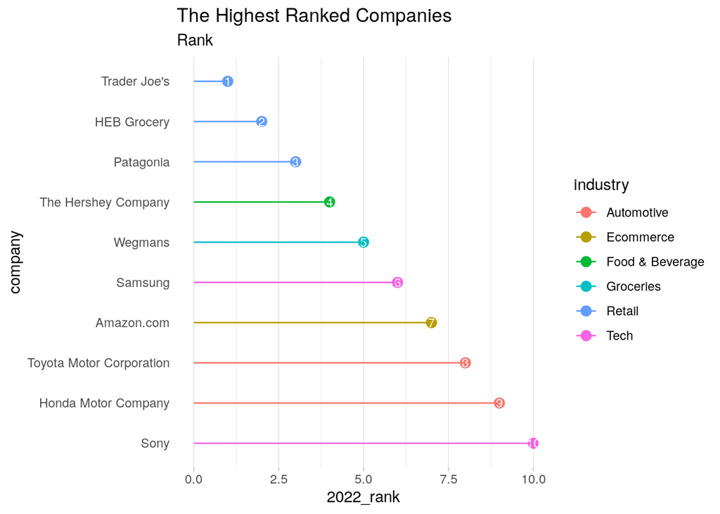

[figure not shown]

In the contrary to the previous figure, this figure shows the lowest ranking companies in their respective category.

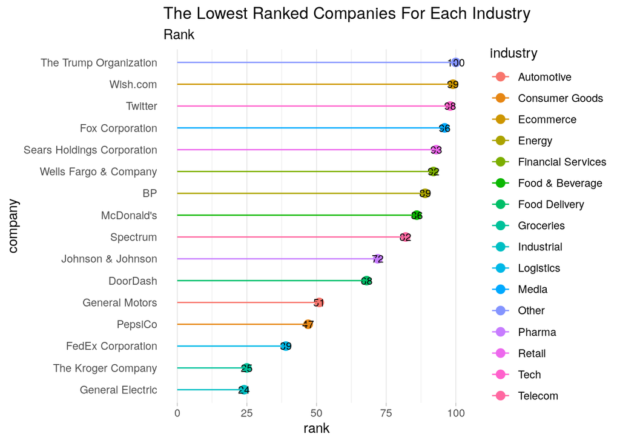

In 2022, most companies achieved “Very Good” reputation standing or above.

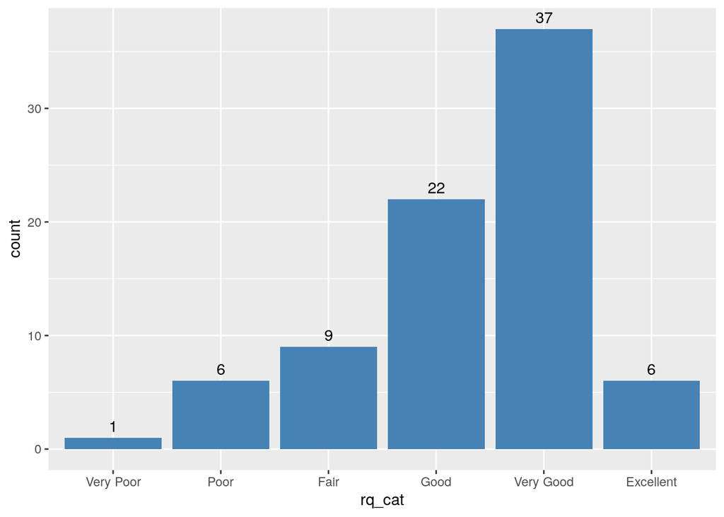

Now, the following figures show some of the major trends for many companies in different categories.

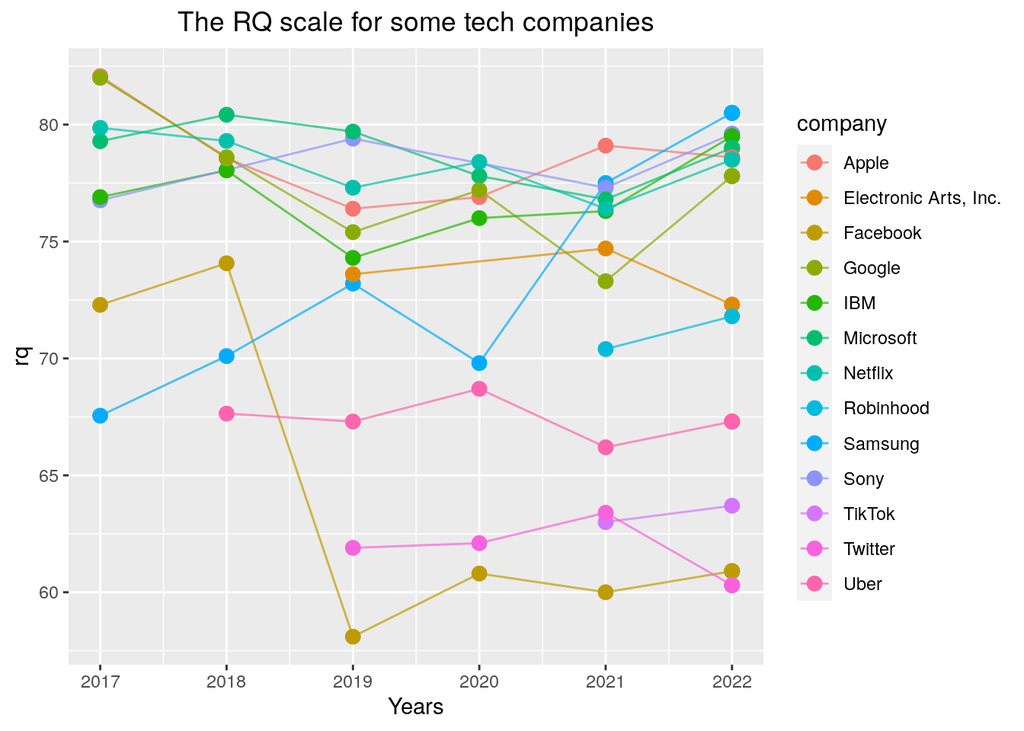

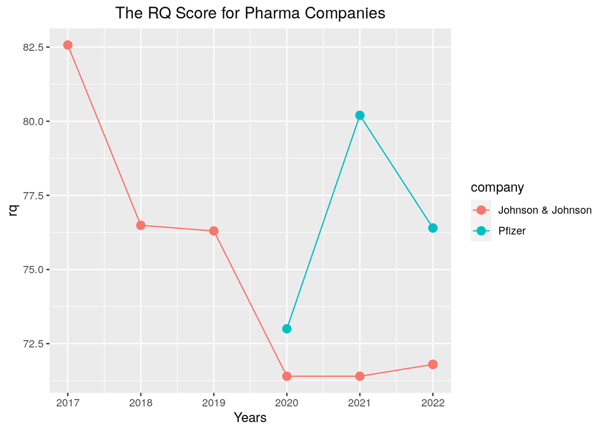

For pharma industry, Johnson & Johnson dominated the scene but its RQ score kept detortiorating until 2020 when a new competitor came to the poll and Johnson & Johnson RQ scores started to settle down.

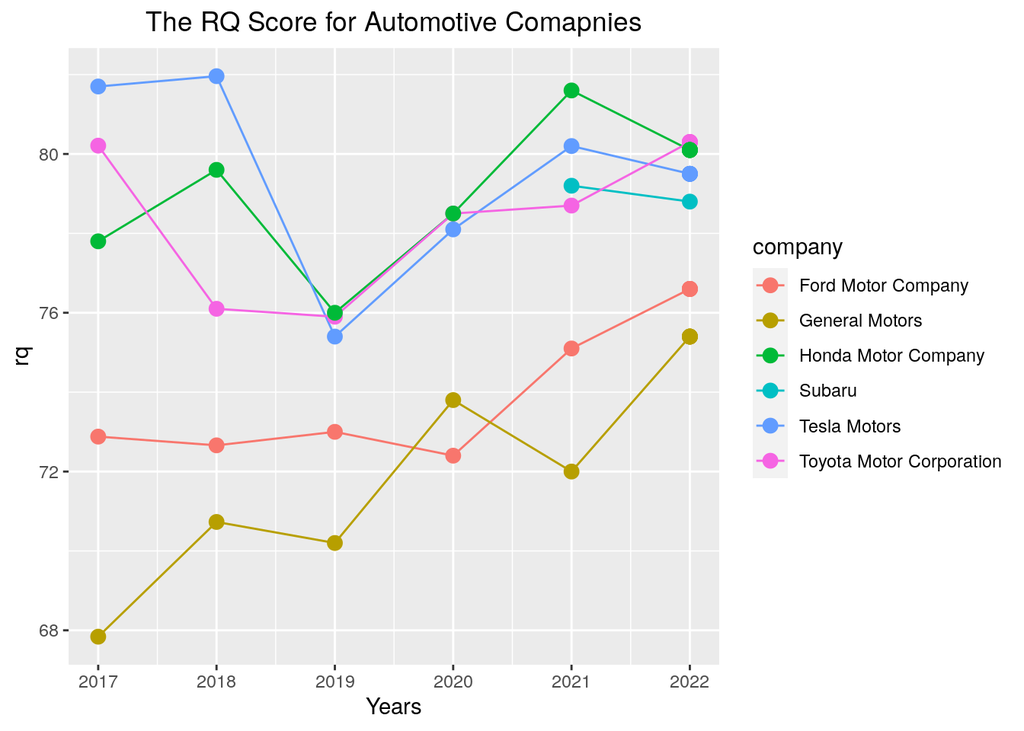

In automotive industry, most companies’ RQ scores has dropped after 2018 but came again to rise after the year of 2019.

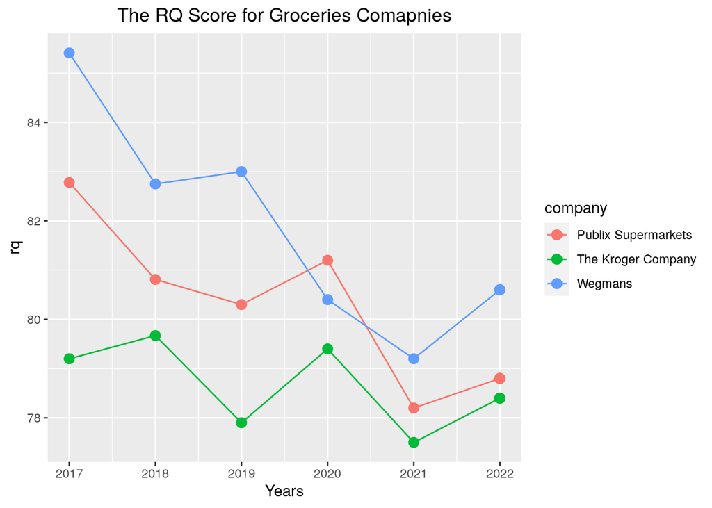

The groceries industry has been in decline since 2017, however, the industry seems to gain RQ scores back in 2022.

## Reputation EDA

### Data munging

The below summary of the reputation shows that the data is clean.

```
##    company            industry             name               score
##  Length:700         Length:700         Length:700         Min.   :51.24
##  Class :character   Class :character   Class :character   1st Qu.:71.57
##  Mode  :character   Mode  :character   Mode  :character   Median :75.92
##                                                           Mean   :74.81
##                                                           3rd Qu.:79.14
##                                                           Max.   :84.92
##       rank
##  Min.   :  1.00
##  1st Qu.: 25.75
##  Median : 50.50
##  Mean   : 50.50
##  3rd Qu.: 75.25
##  Max.   :100.00
```

### Data visualization

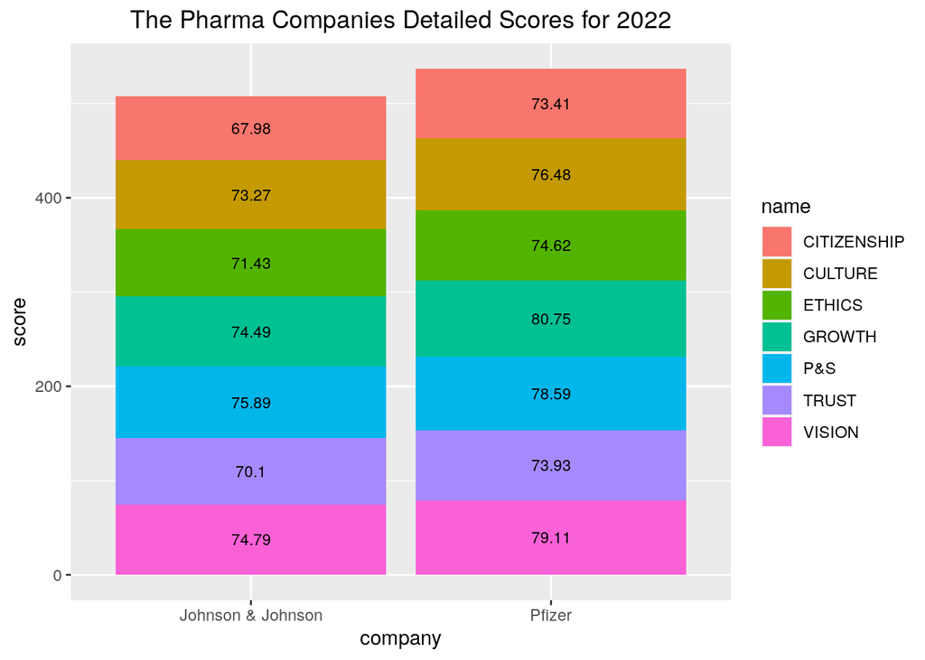

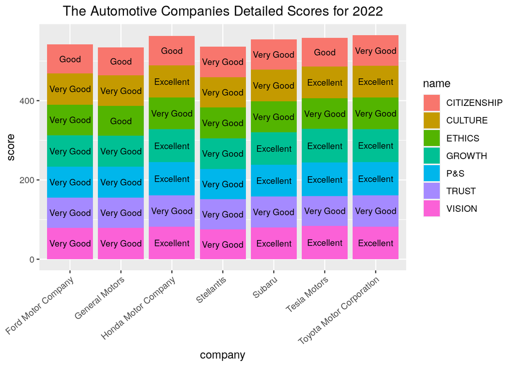

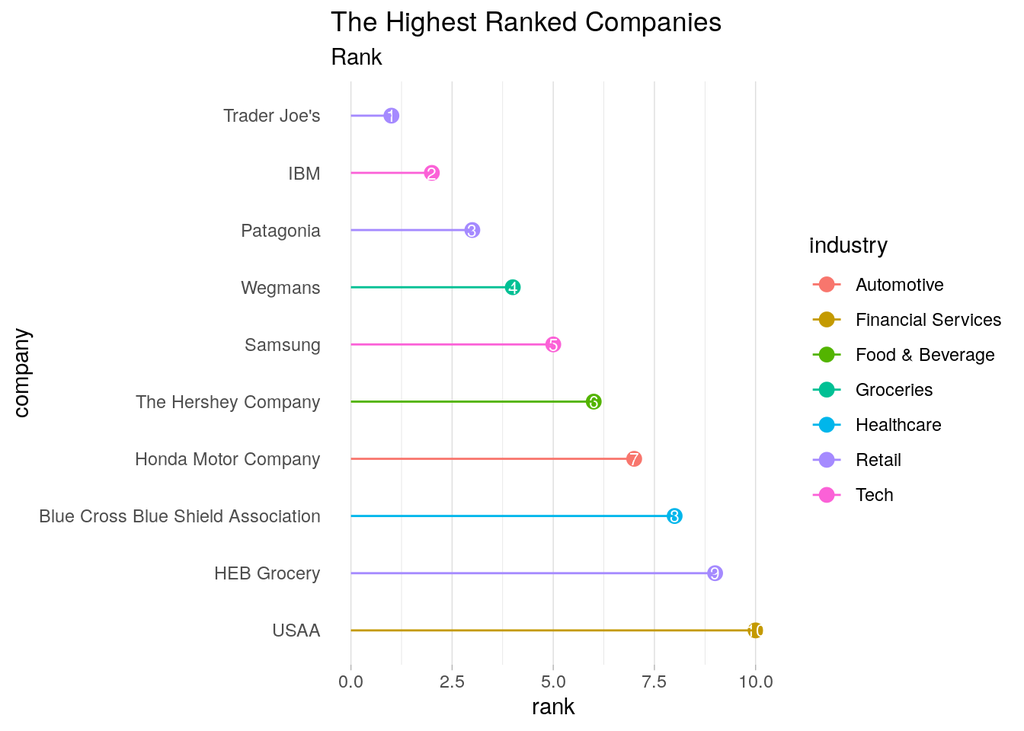

# Hypothesis Testing

H0: β1 = 0 vs H1: β1 ≠ 0

the null hypothesis claims that Rq score does not help us to predict the values of rank to test this hypothesis we fitted a linear model.

```
##
## Call:
## lm(formula = poll$rank ~ poll$rq, data = poll)
##
## Residuals:
##     Min      1Q  Median      3Q     Max
## -62.329  -7.735   0.743   8.659  35.734
##
## Coefficients:
##              Estimate Std. Error t value Pr(>|t|)
## (Intercept) 383.81890    5.54576   69.21   <2e-16 ***
## poll$rq      -4.53044    0.07455  -60.77   <2e-16 ***
## ---
## Signif. codes:  0 '***' 0.001 '**' 0.01 '*' 0.05 '.' 0.1 ' ' 1
##
## Residual standard error: 11.18 on 692 degrees of freedom
## Multiple R-squared:  0.8422, Adjusted R-squared:  0.842
## F-statistic:  3693 on 1 and 692 DF,  p-value: < 2.2e-16
```

```
##                  2.5 %     97.5 %
## (Intercept) 372.930365 394.707429
## poll$rq      -4.676801  -4.384076
```

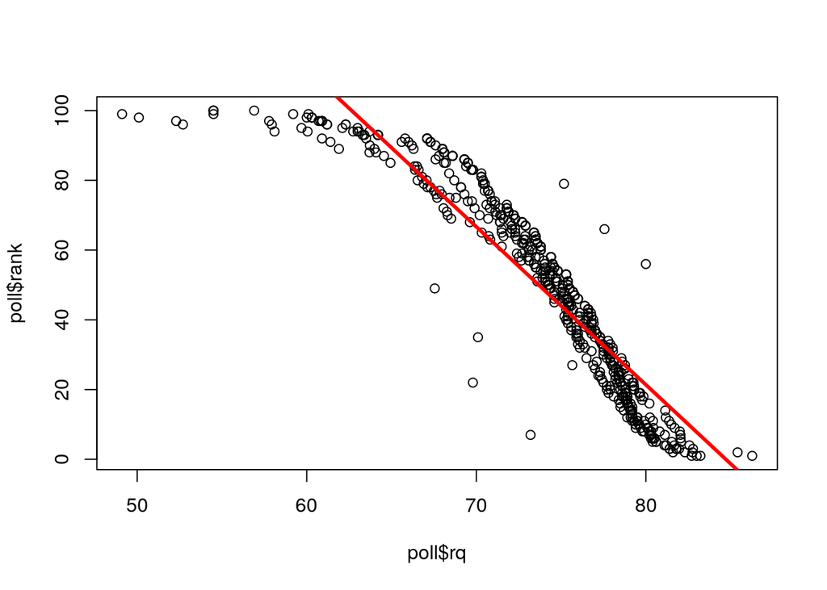

the slope of the regression line is not equal to zero. Thus, we reject the null hypothesis of H0: β1 = 0

# Conclusion